# Assignment 3

# Dataset Description: U.S. Bilateral Trade in Poultry Products

This dataset contains bilateral international trade data for the United States as the reporter country, focusing on the commodity classified under “**meat and edible offal**” of poultry, traded in fresh, chilled, or frozen form.

The dataset includes poultry products, covering common cuts and parts such as breasts, thighs, wings, livers, hearts, and gizzards. It excludes live poultry and processed poultry products.

Trade flows are reported with all countries as partners, meaning the data capture U.S. poultry trade with every trading partner (countries) worldwide. The dataset includes:

- Imports: Poultry products entering the United States from foreign suppliers (e.g., frozen chicken from Brazil or Canada).
- Exports: Poultry products shipped from the United States to international markets (e.g., U.S. poultry exports to Mexico or Asian countries).

# Data Source:

The dataset is obtained from the UN Comtrade database, an open-access repository of official international trade statistics compiled from customs data reported by over 150 countries. Key variables include trade values (USD) and quantities (kilograms), reflecting officially reported bilateral trade flows between the United States and its trading partners.

# General directions

1. For each question, you are encouraged to create a chunk below it, and fully develop the code that creates your answer.
2. You are encouraged to use wrangling functions from the packages `dplyr` and `tidyr`, and plotting functions from the package `ggplot2`.
3. You are encouraged to the the pipe operator (`%>%` or `|>`) to pipe wrangling steps together.
4. For each question, after showing your code and output (be it numerical or graphical), you also need to provide a written sentence of your answer. Just showing code output is not sufficient for full points.
5. As part of the initial wrangling, you are expected to:
- Transform the `qty` column from kg to Mg
- Select only columns that are useful to answer the questions.
6. Check out the following cheatsheets to give you some ideas on wrangling and plotting:
- **ggplot2**: https://posit.co/wp-content/uploads/2022/10/data-visualization-1.pdf
- **dplyr**: https://rstudio.github.io/cheatsheets/data-transformation.pdf

## Dataset

```r
library(readxl) # to read excel files
library(janitor) # to clean data
library(dplyr) # wrangling
library(tidyr) # wrangling
library(readr) # to export csv
library(ggplot2)
```

```r
chicken <- read_csv("03_assignment_data.csv")
# Checking first rows
chicken
```

```
# A tibble: 1,074 × 47
   type_code freq_code ref_period_id ref_year ref_month period reporter_code
   <chr>     <chr>             <dbl>    <dbl>     <dbl>  <dbl>         <dbl>
 1 C         A              20180101     2018        52   2018           842
 2 C         A              20180101     2018        52   2018           842
 3 C         A              20180101     2018        52   2018           842
 4 C         A              20180101     2018        52   2018           842
 5 C         A              20180101     2018        52   2018           842
 6 C         A              20180101     2018        52   2018           842
 7 C         A              20180101     2018        52   2018           842
 8 C         A              20180101     2018        52   2018           842
 9 C         A              20180101     2018        52   2018           842
10 C         A              20180101     2018        52   2018           842
# ℹ 1,064 more rows
# ℹ 40 more variables: reporter_iso <chr>, reporter_desc <chr>,
#   flow_code <chr>, flow_desc <chr>, partner_code <dbl>, partner_iso <chr>,
#   partner_desc <chr>, partner2code <dbl>, partner2iso <chr>,
#   partner2desc <chr>, classification_code <chr>,
#   classification_search_code <chr>, is_original_classification <lgl>,
#   cmd_code <chr>, cmd_desc <chr>, aggr_level <dbl>, is_leaf <lgl>, …
```

```r
glimpse(chicken)
```

```
Rows: 1,074
Columns: 47
$ type_code                  <chr> "C", "C", "C", "C", "C", "C", "C", "C", "C"…
$ freq_code                  <chr> "A", "A", "A", "A", "A", "A", "A", "A", "A"…
$ ref_period_id              <dbl> 20180101, 20180101, 20180101, 20180101, 201…
$ ref_year                   <dbl> 2018, 2018, 2018, 2018, 2018, 2018, 2018, 2…
$ ref_month                  <dbl> 52, 52, 52, 52, 52, 52, 52, 52, 52, 52, 52,…
$ period                     <dbl> 2018, 2018, 2018, 2018, 2018, 2018, 2018, 2…
$ reporter_code              <dbl> 842, 842, 842, 842, 842, 842, 842, 842, 842…
$ reporter_iso               <chr> "USA", "USA", "USA", "USA", "USA", "USA", "…
$ reporter_desc              <chr> "USA", "USA", "USA", "USA", "USA", "USA", "…
$ flow_code                  <chr> "M", "M", "M", "M", "X", "X", "X", "X", "X"…
$ flow_desc                  <chr> "Import", "Import", "Import", "Import", "Ex…
$ partner_code               <dbl> 124, 152, 276, 376, 4, 8, 24, 28, 31, 32, 3…
$ partner_iso                <chr> "CAN", "CHL", "DEU", "ISR", "AFG", "ALB", "…
```

[output cut: 34 more lines]

```r
head(chicken)
```

```
# A tibble: 6 × 47
  type_code freq_code ref_period_id ref_year ref_month period reporter_code
  <chr>     <chr>             <dbl>    <dbl>     <dbl>  <dbl>         <dbl>
1 C         A              20180101     2018        52   2018           842
2 C         A              20180101     2018        52   2018           842
3 C         A              20180101     2018        52   2018           842
4 C         A              20180101     2018        52   2018           842
5 C         A              20180101     2018        52   2018           842
6 C         A              20180101     2018        52   2018           842
# ℹ 40 more variables: reporter_iso <chr>, reporter_desc <chr>,
#   flow_code <chr>, flow_desc <chr>, partner_code <dbl>, partner_iso <chr>,
#   partner_desc <chr>, partner2code <dbl>, partner2iso <chr>,
#   partner2desc <chr>, classification_code <chr>,
#   classification_search_code <chr>, is_original_classification <lgl>,
#   cmd_code <chr>, cmd_desc <chr>, aggr_level <dbl>, is_leaf <lgl>,
#   customs_code <chr>, customs_desc <chr>, mos_code <dbl>, mot_code <dbl>, …
```

# Assignemnt Questions:

## Imports:

#### 1. How many distinct countries were there (based on given data), from where US was importing the poultry products from 2018-2024?

```r
chicken_import <- clean_names(chicken)
chicken_import <- filter(chicken_import, flow_desc == "Import")
chicken_import
```

```
# A tibble: 23 × 47
   type_code freq_code ref_period_id ref_year ref_month period reporter_code
   <chr>     <chr>             <dbl>    <dbl>     <dbl>  <dbl>         <dbl>
 1 C         A              20180101     2018        52   2018           842
 2 C         A              20180101     2018        52   2018           842
 3 C         A              20180101     2018        52   2018           842
 4 C         A              20180101     2018        52   2018           842
 5 C         A              20190101     2019        52   2019           842
 6 C         A              20190101     2019        52   2019           842
 7 C         A              20190101     2019        52   2019           842
 8 C         A              20200101     2020        52   2020           842
 9 C         A              20200101     2020        52   2020           842
10 C         A              20200101     2020        52   2020           842
# ℹ 13 more rows
# ℹ 40 more variables: reporter_iso <chr>, reporter_desc <chr>,
#   flow_code <chr>, flow_desc <chr>, partner_code <dbl>, partner_iso <chr>,
#   partner_desc <chr>, partner2code <dbl>, partner2iso <chr>,
#   partner2desc <chr>, classification_code <chr>,
#   classification_search_code <chr>, is_original_classification <lgl>,
#   cmd_code <chr>, cmd_desc <chr>, aggr_level <dbl>, is_leaf <lgl>, …
```

```r
#count unique values in partner column
unique_countries <- n_distinct(chicken_import$partner_desc)
unique_countries
```

```
[1] 7
```

##### *There were 7 unique countries the U.S. was importing from during the 2018-2024 period.*

#### 2. What are the minimum, maximum trade values for imports? Mention the country, year and its respective value.

```r
#mutate import qty from kg to Mg
import_01 <- mutate(chicken_import,
                  qty_mg = qty*1000000,
                  qty_mg= round(qty_mg, 0)
                  )
import_01
```

```
# A tibble: 23 × 48
   type_code freq_code ref_period_id ref_year ref_month period reporter_code
   <chr>     <chr>             <dbl>    <dbl>     <dbl>  <dbl>         <dbl>
 1 C         A              20180101     2018        52   2018           842
 2 C         A              20180101     2018        52   2018           842
 3 C         A              20180101     2018        52   2018           842
 4 C         A              20180101     2018        52   2018           842
 5 C         A              20190101     2019        52   2019           842
 6 C         A              20190101     2019        52   2019           842
 7 C         A              20190101     2019        52   2019           842
 8 C         A              20200101     2020        52   2020           842
 9 C         A              20200101     2020        52   2020           842
10 C         A              20200101     2020        52   2020           842
# ℹ 13 more rows
# ℹ 41 more variables: reporter_iso <chr>, reporter_desc <chr>,
#   flow_code <chr>, flow_desc <chr>, partner_code <dbl>, partner_iso <chr>,
#   partner_desc <chr>, partner2code <dbl>, partner2iso <chr>,
#   partner2desc <chr>, classification_code <chr>,
#   classification_search_code <chr>, is_original_classification <lgl>,
#   cmd_code <chr>, cmd_desc <chr>, aggr_level <dbl>, is_leaf <lgl>, …
```

```r
#summarize for mean, minimum, maximum, etc.
import_sum <- select(import_01, ref_year, period, flow_desc,
 partner_desc, qty_unit_abbr, qty, primary_value, qty_mg
)
import_sum
```

```
# A tibble: 23 × 8
   ref_year period flow_desc partner_desc qty_unit_abbr      qty primary_value
      <dbl>  <dbl> <chr>     <chr>        <chr>            <dbl>         <dbl>
 1     2018   2018 Import    Canada       kg            31582204     117042640
 2     2018   2018 Import    Chile        kg            40202179     139757883
 3     2018   2018 Import    Germany      kg               66053        206221
 4     2018   2018 Import    Israel       kg             1693018       8305053
 5     2019   2019 Import    Canada       kg            25899826     107515496
 6     2019   2019 Import    Chile        kg            40759904     131188057
 7     2019   2019 Import    Israel       kg             1025837       4737344
 8     2020   2020 Import    Canada       kg            28479509     112060969
 9     2020   2020 Import    Chile        kg            48575220     159895782
10     2020   2020 Import    China        kg               15008        106106
# ℹ 13 more rows
# ℹ 1 more variable: qty_mg <dbl>
```

```r
import_sort <- arrange(import_sum, primary_value)
import_sort
```

```
# A tibble: 23 × 8
   ref_year period flow_desc partner_desc qty_unit_abbr      qty primary_value
      <dbl>  <dbl> <chr>     <chr>        <chr>            <dbl>         <dbl>
 1     2022   2022 Import    Poland       kg                 420          4308
 2     2020   2020 Import    China        kg               15008        106106
 3     2018   2018 Import    Germany      kg               66053        206221
 4     2023   2023 Import    Mexico       kg              204265        248875
 5     2024   2024 Import    Mexico       kg              187120        267323
 6     2022   2022 Import    Mexico       kg              339659       1107585
 7     2021   2021 Import    Mexico       kg              798645       2487672
 8     2019   2019 Import    Israel       kg             1025837       4737344
 9     2018   2018 Import    Israel       kg             1693018       8305053
10     2019   2019 Import    Canada       kg            25899826     107515496
# ℹ 13 more rows
# ℹ 1 more variable: qty_mg <dbl>
```

##### *The minimum value for trade imports came from Poland in 2022 at 4308 (primary value based on FOB or CIF). The maximum value came from Chile in 2022 at 428214676 primary value.*

#### 3. Identify the top 5 countries from which the USA imported the most (qty) in the years 2018 and 2024. List the countries and their corresponding import values.

```r
### Piping it all together
import_2018 <- chicken %>%
  clean_names() %>%
  filter(flow_desc == "Import") %>%
  filter(ref_year == "2018") %>%
  mutate(qty_mg = qty*1000000,
                  qty_mg= round(qty_mg, 0) )%>%
 dplyr::select(ref_year, period, flow_desc,
 partner_desc, qty_unit_abbr, qty, primary_value, qty_mg
 )%>%

  arrange(
                  qty_mg
                  )


import_2018
```

```
# A tibble: 4 × 8
  ref_year period flow_desc partner_desc qty_unit_abbr      qty primary_value
     <dbl>  <dbl> <chr>     <chr>        <chr>            <dbl>         <dbl>
1     2018   2018 Import    Germany      kg               66053        206221
2     2018   2018 Import    Israel       kg             1693018       8305053
3     2018   2018 Import    Canada       kg            31582204     117042640
4     2018   2018 Import    Chile        kg            40202179     139757883
# ℹ 1 more variable: qty_mg <dbl>
```

#### *For 2018, there were only four countries with top imported values included Germany at 6.605300e+10 mg, Israel at 1.693018e+12 mg,Canada at 3.158220e+13 mg, and Chile at 4.020218e+13 mg.*

```r
###Piping it all together
import_2024 <- chicken %>%
  clean_names() %>%
  filter(flow_desc == "Import") %>%
  filter(ref_year == "2024") %>%
  mutate(qty_mg = qty*1000000,
                  qty_mg= round(qty_mg, 0) )%>%
 dplyr::select(ref_year, period, flow_desc,
 partner_desc, qty_unit_abbr, qty, primary_value, qty_mg
)%>%

  arrange(
                  qty_mg
                  )


import_2024
```

```
# A tibble: 3 × 8
  ref_year period flow_desc partner_desc qty_unit_abbr      qty primary_value
     <dbl>  <dbl> <chr>     <chr>        <chr>            <dbl>         <dbl>
1     2024   2024 Import    Mexico       kg              187120        267323
2     2024   2024 Import    Canada       kg            31792552     146943943
3     2024   2024 Import    Chile        kg            55309008     222025539
# ℹ 1 more variable: qty_mg <dbl>
```

#### *For 2024, there were only three import countries with the top values being 1.871200e+11 mg for Mexico, 3.179255e+13 mg for Canada, and 5.530901e+13 mg for Chile.*

#### 4. Calculate the total import value for the USA from each country. Which country had the highest total export value **to** US, and what was that value?

```r
###Sum Imports Per Country
import_total <- chicken %>%
  clean_names() %>%
  filter(flow_desc == "Import") %>%
  mutate(qty_mg = qty*1000000,
                  qty_mg= round(qty_mg, 0) )%>%
 dplyr::select(ref_year, period, flow_desc,
 partner_desc, qty_unit_abbr, qty, primary_value, qty_mg
)%>%

group_by(partner_desc) %>%
summarize(sum_value = sum(primary_value))%>%
arrange(1/sum_value)

import_total
```

```
# A tibble: 7 × 2
  partner_desc  sum_value
  <chr>             <dbl>
1 Chile        1532686723
2 Canada        877439908
3 Israel         13042397
4 Mexico          4111455
5 Germany          206221
6 China            106106
7 Poland             4308
```

#### *The country with the largest sum export value to the US was Chile, at a primary value of 1532686723.*

#### 5. Calculate the total import value for the USA in each year from 2018 to 2025. Which year had the highest total import value, and what was that value?

```r
###Sum Imports Per YEAR
import_total <- chicken %>%
  clean_names() %>%
  filter(flow_desc == "Import") %>%
  mutate(qty_mg = qty*1000000,
                  qty_mg= round(qty_mg, 0) )%>%
 dplyr::select(ref_year, period, flow_desc,
 partner_desc, qty_unit_abbr, qty, primary_value, qty_mg
)%>%

group_by(ref_year) %>%
summarize(sum_value = sum(primary_value))%>%
arrange(1/sum_value)

import_total
```

```
# A tibble: 7 × 2
  ref_year sum_value
     <dbl>     <dbl>
1     2022 566412591
2     2021 383046235
3     2024 369236805
4     2023 328085936
5     2020 272062857
6     2018 265311797
7     2019 243440897
```

#### *The year with the highest total import value was 2022 with a primary value of 566412591.*

#### 6. Plot a line graph showing the total annual import value for the USA from 2018 to 2024. Describe any noticeable trends or patterns (e.g., increases, decreases, or fluctuations) in the graph. Create a publication ready plot.

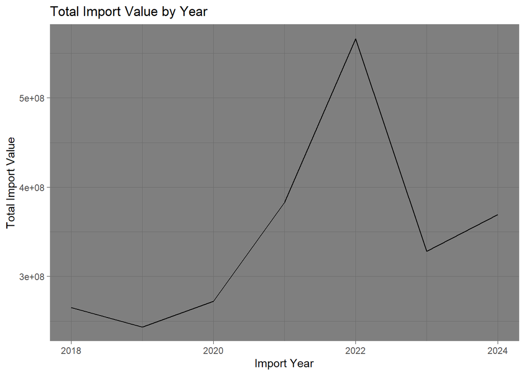

```r
###Total Annual Import Value, USA 2018-2024



ggplot(import_total, aes(x = ref_year, y = sum_value))+
  geom_line()+
labs(
    x = "Import Year",
    y = "Total Import Value",
    title = "Total Import Value by Year"
  )+
  theme_dark()
```

#### *The figure above shows total import values by year for the US.We can see a noticeable trend from 2020 through 2022 were total import values dramatically rose, then tanked within a year as 2023 settled in.*

## Exports:

#### 7. How many distinct countries were there (based on given data), to where US was exporting the poultry products?

```r
chicken_export <- chicken %>%
clean_names() %>%
filter(flow_desc == "Export")%>%
mutate(qty_mg = qty*1000000,
                  qty_mg= round(qty_mg, 0) )%>%
 dplyr::select(ref_year, period, flow_desc,
 partner_desc, qty_unit_abbr, qty, primary_value, qty_mg
)

chicken_export
```

```
# A tibble: 1,051 × 8
   ref_year period flow_desc partner_desc     qty_unit_abbr    qty primary_value
      <dbl>  <dbl> <chr>     <chr>            <chr>          <dbl>         <dbl>
 1     2018   2018 Export    Afghanistan      kg            2.49e7      19773534
 2     2018   2018 Export    Albania          kg            1.03e7       8430470
 3     2018   2018 Export    Angola           kg            2.09e8     183671360
 4     2018   2018 Export    Antigua and Bar… kg            4.28e6       5675517
 5     2018   2018 Export    Azerbaijan       kg            5.44e5        297109
 6     2018   2018 Export    Argentina        kg            7.74e4         59264
 7     2018   2018 Export    Australia        kg            2.59e5        703432
 8     2018   2018 Export    Austria          kg            2.82e4         23293
 9     2018   2018 Export    Bahamas          kg            1.33e7      23028334
10     2018   2018 Export    Bahrain          kg            7.07e6       5991050
# ℹ 1,041 more rows
# ℹ 1 more variable: qty_mg <dbl>
```

```r
#count unique values in partner column
unique_countries <- n_distinct(chicken_export$partner_desc)
unique_countries
```

```
[1] 188
```

```r
#summarize for mean, minimum, maximum, etc.
chicken_export <- chicken %>%
clean_names() %>%
filter(flow_desc == "Export")%>%
mutate(qty_mg = qty*1000000,
                  qty_mg= round(qty_mg, 0) )%>%
 dplyr::select(ref_year, period, flow_desc,
 partner_desc, qty_unit_abbr, qty, primary_value, qty_mg
) %>%
arrange(primary_value)

chicken_export
```

```
# A tibble: 1,051 × 8
   ref_year period flow_desc partner_desc qty_unit_abbr   qty primary_value
      <dbl>  <dbl> <chr>     <chr>        <chr>         <dbl>         <dbl>
 1     2018   2018 Export    Czechia      kg             3507          2900
 2     2019   2019 Export    Fiji         kg              835          3113
 3     2020   2020 Export    Finland      kg              599          3234
 4     2022   2022 Export    Finland      kg              638          3250
 5     2020   2020 Export    Cyprus       kg             2631          3512
 6     2019   2019 Export    Argentina    kg              275          3740
 7     2022   2022 Export    Malta        kg              251          3993
 8     2021   2021 Export    Austria      kg              726          4160
 9     2022   2022 Export    Brazil       kg             4025          4211
10     2021   2021 Export    Romania      kg             1637          4258
# ℹ 1,041 more rows
# ℹ 1 more variable: qty_mg <dbl>
```

#### 9. Identify the top 5 countries to which the USA exported the most (qty) in the years 2018 and 2024. List the countries and their corresponding export values.

```r
###Piping it all together
export_2018 <- chicken %>%
  clean_names() %>%
  filter(flow_desc == "Export") %>%
  filter(ref_year == "2018") %>%
  mutate(qty_mg = qty*1000000,
                  qty_mg= round(qty_mg, 0) )%>%
 dplyr::select(ref_year, period, flow_desc,
 partner_desc, qty_unit_abbr, qty, primary_value, qty_mg
)%>%

  arrange(
                  qty_mg
                  )


export_2018
```

```
# A tibble: 157 × 8
   ref_year period flow_desc partner_desc qty_unit_abbr   qty primary_value
      <dbl>  <dbl> <chr>     <chr>        <chr>         <dbl>         <dbl>
 1     2018   2018 Export    Brazil       kg             2480          7053
 2     2018   2018 Export    Czechia      kg             3507          2900
 3     2018   2018 Export    Yemen        kg             5542          8250
 4     2018   2018 Export    Finland      kg             7389          4595
 5     2018   2018 Export    Sweden       kg             8026         29150
 6     2018   2018 Export    Paraguay     kg            10821         50639
 7     2018   2018 Export    Ireland      kg            12828         10608
 8     2018   2018 Export    Kiribati     kg            13653         30585
 9     2018   2018 Export    Sri Lanka    kg            17447         60311
10     2018   2018 Export    Malta        kg            22733         18798
# ℹ 147 more rows
# ℹ 1 more variable: qty_mg <dbl>
```

##### *In 2018, the country with the largest export quantity was Mexico at 7.928131e+14 mg, followed by China, Hong Kong SAR at 2.917131e+14 mg, Other Asia at 2.093894e+14 mg, Cuba at 2.024927e+14 mg, and Canada at 1.952350e+14 mg .*

```r
###Piping it all together

export_2024 <- chicken %>%
  clean_names() %>%
  filter(flow_desc == "Export") %>%
  filter(ref_year == "2024") %>%
  mutate(qty_mg = qty*1000000,
                  qty_mg= round(qty_mg, 0) )%>%
 dplyr::select(ref_year, period, flow_desc,
 partner_desc, qty_mg, qty_unit_abbr, qty, primary_value
)%>%

  arrange(
                  1/qty_mg
                  )


export_2024
```

```
# A tibble: 143 × 8
   ref_year period flow_desc partner_desc          qty_mg qty_unit_abbr      qty
      <dbl>  <dbl> <chr>     <chr>                  <dbl> <chr>            <dbl>
 1     2024   2024 Export    Mexico               8.53e14 kg              8.53e8
 2     2024   2024 Export    Cuba                 2.40e14 kg              2.40e8
 3     2024   2024 Export    Other Asia, nes      2.10e14 kg              2.10e8
 4     2024   2024 Export    Philippines          1.63e14 kg              1.63e8
 5     2024   2024 Export    Canada               1.48e14 kg              1.48e8
 6     2024   2024 Export    China                1.41e14 kg              1.41e8
 7     2024   2024 Export    Viet Nam             1.37e14 kg              1.37e8
 8     2024   2024 Export    Guatemala            1.35e14 kg              1.35e8
 9     2024   2024 Export    Angola               1.20e14 kg              1.20e8
10     2024   2024 Export    China, Hong Kong SAR 8.24e13 kg              8.24e7
# ℹ 133 more rows
# ℹ 1 more variable: primary_value <dbl>
```

##### *In 2024, the 5 countries with the largest export quantities in mg were Mexico at 8.529040e+14 mg, followed by Cuba at 2.396432e+14 mg, Other Asia at 2.100486e+14 mg, Philippines at 1.630840e+14 mg, and Canada at 1.481891e+14 mg.*

#### 10. Calculate the total export value for the USA from each country. Which country had the highest total import value **from** US, and what was that value?

```r
###Sum Exports Per Country
export_total <- chicken %>%
  clean_names() %>%
  filter(flow_desc == "Export") %>%
  mutate(qty_mg = qty*1000000,
                  qty_mg= round(qty_mg, 0) )%>%
 dplyr::select(ref_year, period, flow_desc,
 partner_desc, qty_mg, qty_unit_abbr, qty, primary_value
)%>%

group_by(partner_desc) %>%
summarize(sum_value = sum(primary_value))%>%
arrange(1/sum_value)

export_total
```

```
# A tibble: 188 × 2
   partner_desc          sum_value
   <chr>                     <dbl>
 1 Mexico               6823047519
 2 China                3813940305
 3 Canada               2227869347
 4 Other Asia, nes      1674974582
 5 Cuba                 1635093053
 6 China, Hong Kong SAR 1143876295
 7 Angola               1028925256
 8 Guatemala            1004824791
 9 Philippines           978700870
10 Viet Nam              869091874
# ℹ 178 more rows
```

##### *The country with the highest import value, or value exported from the US, was Mexico with a total primary trade value of 6823047519.*

#### 11. Calculate the total export value for the USA in each year from 2018 to 2025. Which year had the highest total export value, and what was that value?

```r
###Sum Exports Per Year
export_total <- chicken %>%
  clean_names() %>%
  filter(flow_desc == "Export") %>%
  mutate(qty_mg = qty*1000000,
                  qty_mg= round(qty_mg, 0) )%>%
 dplyr::select(ref_year, period, flow_desc,
 partner_desc, qty_mg, qty_unit_abbr, qty, primary_value
)%>%

group_by(ref_year) %>%
summarize(sum_value = sum(primary_value))%>%
arrange(1/sum_value)

export_total
```

```
# A tibble: 7 × 2
  ref_year  sum_value
     <dbl>      <dbl>
1     2022 5401343250
2     2023 4886389111
3     2021 4772894502
4     2024 4766297796
5     2020 3837181558
6     2019 3749261464
7     2018 3628826731
```

##### *The highest net export value was observed for 2022, totaling at 5401343250 for the primary trade value.*

#### 12. Plot a line graph showing the total annual export value for the USA from 2018 to 2024. Describe any noticeable trends or patterns (e.g., increases, decreases, or fluctuations) in the graph. Create a publication ready plot.

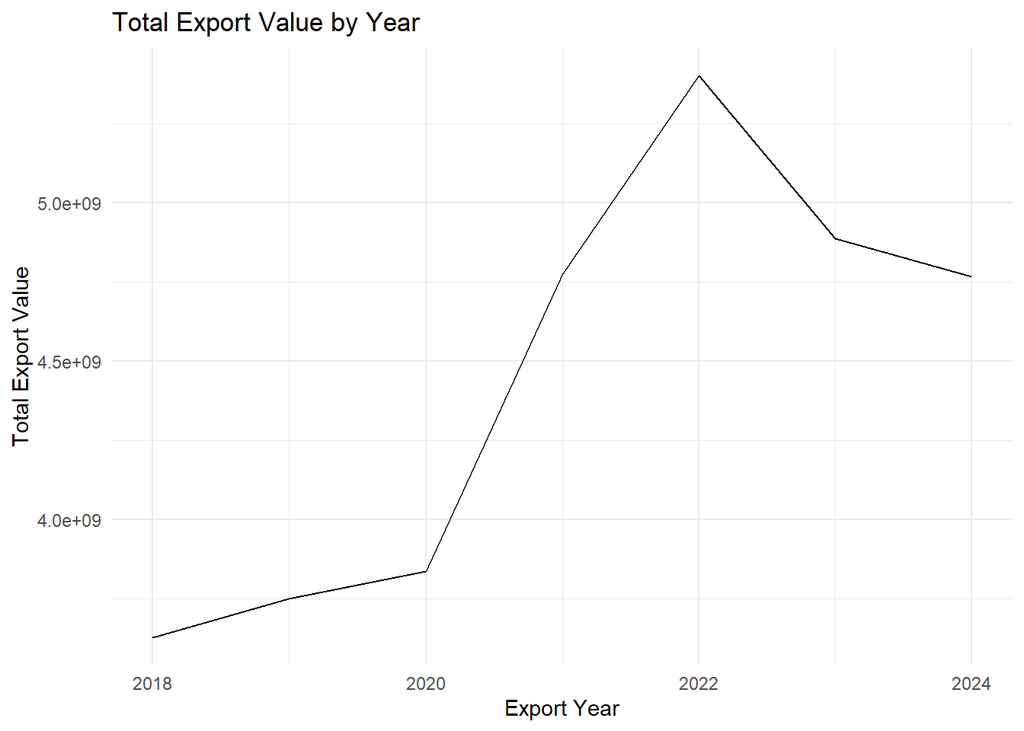

```r
###Total Annual Import Value, USA 2018-2024



ggplot(export_total, aes(x = ref_year, y = sum_value))+
  geom_line()+
labs(
    x = "Export Year",
    y = "Total Export Value",
    title = "Total Export Value by Year"
  )+
  theme_minimal()
```

#### *The above figure shows total export values by year for the U.S., with a clear increase and change in the trend being observed starting in 2020 and going through 2022, where a peak total export value is reached before a less dramatic decline in total export value begins from 2022 going into 2023 and continuing onward.*

## Imports - Exports Comparision:

#### 13. Does the U.S. behave more as a net importer or net exporter for this commodity? Explore it:

- Based on total value US imports and exports.
- Based on number of countries US imports and exports
- Based on each year’s import export value.

```r
###Sum Per Export/Import
chicken_total <- chicken %>%
  clean_names() %>%
  mutate(qty_mg = qty*1000000,
                  qty_mg= round(qty_mg, 0) )%>%
 dplyr::select(ref_year, period, flow_desc,
 partner_desc, qty_mg, qty_unit_abbr, qty, primary_value
)%>%

group_by(flow_desc) %>%
summarize(sum_value = sum(primary_value))%>%
arrange(1/sum_value)

chicken_total
```

```
# A tibble: 2 × 2
  flow_desc   sum_value
  <chr>           <dbl>
1 Export    31042194412
2 Import     2427597118
```

```r
###Sum Per Export/Import
chicken_total <- chicken %>%
  clean_names() %>%
  mutate(qty_mg = qty*1000000,
                  qty_mg= round(qty_mg, 0) )%>%
 dplyr::select(ref_year, period, flow_desc,
 partner_desc, qty_mg, qty_unit_abbr, qty, primary_value
)%>%

group_by(flow_desc, ref_year) %>%
summarize(sum_value = sum(primary_value))%>%
arrange(1/sum_value)
chicken_total
```

```
# A tibble: 14 × 3
# Groups:   flow_desc [2]
   flow_desc ref_year  sum_value
   <chr>        <dbl>      <dbl>
 1 Export        2022 5401343250
 2 Export        2023 4886389111
 3 Export        2021 4772894502
 4 Export        2024 4766297796
 5 Export        2020 3837181558
 6 Export        2019 3749261464
 7 Export        2018 3628826731
 8 Import        2022  566412591
 9 Import        2021  383046235
10 Import        2024  369236805
11 Import        2023  328085936
12 Import        2020  272062857
13 Import        2018  265311797
14 Import        2019  243440897
```

##### *Given that a sum trade value of 31042194412 was observed for all exports compared to only 2427597118 for all historic US imports, and given that the highest two export/import values observed per year were both for exports in 2022 and 2023, it is fair to say the U.S. is primarily in the chicken export market as a net exporter. This is further supported by the fact that they have 188 countries they export to compared to only 7 countries for imports.*

#### 14. Are the main import partners also major export destinations? Explore it based on the total import export value by countries.

```r
###Sum Per Export/Import
chicken_country <- chicken %>%
  clean_names() %>%
  mutate(qty_mg = qty*1000000,
                  qty_mg= round(qty_mg, 0) )%>%
 dplyr::select(ref_year, period, flow_desc,
 partner_desc, qty_mg, qty_unit_abbr, qty, primary_value
)%>%

group_by(flow_desc, partner_desc) %>%
summarize(sum_value = sum(primary_value))%>%
arrange(1/sum_value)
chicken_country
```

```
# A tibble: 195 × 3
# Groups:   flow_desc [2]
   flow_desc partner_desc          sum_value
   <chr>     <chr>                     <dbl>
 1 Export    Mexico               6823047519
 2 Export    China                3813940305
 3 Export    Canada               2227869347
 4 Export    Other Asia, nes      1674974582
 5 Export    Cuba                 1635093053
 6 Import    Chile                1532686723
 7 Export    China, Hong Kong SAR 1143876295
 8 Export    Angola               1028925256
 9 Export    Guatemala            1004824791
10 Export    Philippines           978700870
# ℹ 185 more rows
```

```r
###Sum Per Export/Import
chicken_imp <- chicken %>%
  clean_names() %>%
  filter(flow_desc == "Import") %>%
  mutate(qty_mg = qty*1000000,
                  qty_mg= round(qty_mg, 0) )%>%
 dplyr::select(ref_year, period, flow_desc,
 partner_desc, qty_mg, qty_unit_abbr, qty, primary_value
)%>%

group_by(partner_desc) %>%
summarize(sum_value = sum(primary_value))%>%
arrange(1/sum_value)

chicken_imp
```

```
# A tibble: 7 × 2
  partner_desc  sum_value
  <chr>             <dbl>
1 Chile        1532686723
2 Canada        877439908
3 Israel         13042397
4 Mexico          4111455
5 Germany          206221
6 China            106106
7 Poland             4308
```

```r
###Sum Per Export/Import
chicken_imp <- chicken %>%
  clean_names() %>%
  filter(flow_desc == "Export") %>%
  mutate(qty_mg = qty*1000000,
                  qty_mg= round(qty_mg, 0) )%>%
 dplyr::select(ref_year, period, flow_desc,
 partner_desc, qty_mg, qty_unit_abbr, qty, primary_value
)%>%

group_by(partner_desc) %>%
summarize(sum_value = sum(primary_value))%>%
arrange(1/sum_value)

chicken_imp
```

```
# A tibble: 188 × 2
   partner_desc          sum_value
   <chr>                     <dbl>
 1 Mexico               6823047519
 2 China                3813940305
 3 Canada               2227869347
 4 Other Asia, nes      1674974582
 5 Cuba                 1635093053
 6 China, Hong Kong SAR 1143876295
 7 Angola               1028925256
 8 Guatemala            1004824791
 9 Philippines           978700870
10 Viet Nam              869091874
# ℹ 178 more rows
```

##### *The top highest value export countries include Mexico, China, Canada, Other Asia, and Cuba. The top highest value import countries include Chile, Canada, Israel, Mexico, and Germany.Therefore there is some overlap with the main import partners such as Canada and Mexico being major export partners, but that is only 2 out 5 for the top five import and export countries based on trade value, so it is not the majority of import partners.*

#### 15. Can you calculate if US is in trade surplus or trade deficit for each year from 2018-2024?

$$\text{Trade surplus or deficit} = \text{Imports} - \text{Exports}$$

```r
#full_join( x y by="common ref")
vandaley <- full_join(import_total, export_total, by="ref_year") %>%
  mutate(deficit = sum_value.x - sum_value.y) %>%
  select(ref_year, deficit)

vandaley
```

```
# A tibble: 7 × 2
  ref_year     deficit
     <dbl>       <dbl>
1     2022 -4834930659
2     2021 -4389848267
3     2024 -4397060991
4     2023 -4558303175
5     2020 -3565118701
6     2018 -3363514934
7     2019 -3505820567
```

# Submitting your work

Once you have developed all the code and answers, make sure to Render this quarto file.

**Notes on rendering**:

- Make sure to render your work and inspect how the final html look like.
- If it does not look professional for whatever reason, then fix the issue, re-render it, recheck.
- Only send me your work once your html file looks professional.
- Some potential issues you may encounter and how to fix them:
  - Some times your code may be creating a table output that is waaay to long and cumbersome to scroll through when rendered. If this is the case, make it more professional looking by using the `head()` function to only print the first handful of rows (instead of thousands of rows).
  - **DO NOT** delete the file’s heading levels (# and ##). They set up the proper heading 1 and 2 levels, and I use them to guide my grading.
  - There’s a total of **15 questions**. If you mess around with the heading levels and you get a different number of questions on the rendered version, fix it.
  - If a given chunk is also outputting warnings or messages, inhibit this behavior by changing the chunk options `message` and `warning` to `FALSE` (I’ll demo this in a moment).
  - If, after rendered, 2 lines of text are connected and you wish to “break line” between them, add 2 extra spaces after the first one (I’lld demo this in a moment).

After rendering, an .html file will be created on your `code` folder.

Rename this file to `03_assignment_LASTNAME.html`.

For ex., `03_assignment_Bastos.html`.

Submit the html file on eLC by Monday Feb 2nd 11:59 pm, **one week** from today.